# Data Science I, Workshop I: Predicting interest rates at the Lending Club

Group 2

12/10/2021

This workshop partially replicates the analysis presented in class (lectures 1 and 2) and builds on it. You are to work in your study group. Feel free to refer to the “Lending_Club_Session1_and_2.html” if you get stuck.

The workshop consists of 11 questions. Submit one report (one file) per study group.

*Please write your answer below each question and submit a knitted RMD markup file as the HTML file via Canvas, within 6 days after the end of this workshop. Please note that there is a 20% penalty on your Workshop Report 1 grade if you submit an RMD file.*

Please keep your answers concise – focus on answering what you are asked and use your data science work to justify your answers. Do not focus on the process you have followed to reach the answer.

# 1 Load and prepare the data

We start by loading the data to R in a dataframe.

```r
lc_raw <- read_csv("LendingClub Data.csv",  skip=1) %>%  #since the first row is a title we want to skip it.
  clean_names() # use janitor::clean_names()
```

# 2 ICE the data: Inspect, Clean, Explore

Any data science engagement starts with ICE. Inspect, Clean and Explore the data. For this workshop I have cleaned the data for you.

```r
glimpse(lc_raw)
```

```
## Rows: 42,538
## Columns: 80
## $ int_rate            <dbl> 0.05, 0.05, 0.05, 0.05, 0.05, 0.05, 0.05, 0.05, 0.…
## $ loan_amnt           <dbl> 8000, 6000, 6500, 8000, 5500, 6000, 10200, 15000, …
## $ term_months         <dbl> 36, 36, 36, 36, 36, 36, 36, 36, 36, 36, 36, 36, 36…
## $ installment         <dbl> 241.28, 180.96, 196.04, 241.28, 165.88, 180.96, 30…
## $ dti                 <dbl> 2.11, 5.73, 17.68, 22.71, 5.75, 21.92, 18.62, 9.72…
## $ delinq_2yrs         <dbl> 0, 0, 0, 0, 0, 0, 0, 0, 0, 0, 0, 0, 0, 0, 0, 0, 0,…
## $ annual_inc          <dbl> 50000, 52800, 35352, 79200, 240000, 89000, 110000,…
## $ grade               <chr> "A", "A", "A", "A", "A", "A", "A", "A", "A", "A", …
## $ emp_title           <chr> NA, "coral graphics", NA, "Honeywell", "O T Plus, …
## $ emp_length          <chr> "5 years", "< 1 year", "n/a", "n/a", "10+ years", …
## $ home_ownership      <chr> "MORTGAGE", "MORTGAGE", "MORTGAGE", "MORTGAGE", "M…
## $ verification_status <chr> "Verified", "Source Verified", "Not Verified", "Ve…
## $ issue_d             <chr> "9/1/2011", "9/1/2011", "9/1/2011", "9/1/2011", "9…
```

[output cut: 67 more lines]

```r
lc_clean<- lc_raw %>%
  dplyr::select(-x20:-x80) %>% #delete empty columns
  filter(!is.na(int_rate)) %>%   #delete empty rows
  mutate(
    issue_d = mdy(issue_d),  # lubridate::mdy() to fix date format
    term = factor(term_months),     # turn 'term' into a categorical variable
    delinq_2yrs = factor(delinq_2yrs) # turn 'delinq_2yrs' into a categorical variable
  ) %>%
  dplyr::select(-emp_title,-installment, -term_months, everything()) #move some not-so-important variables to the end.


glimpse(lc_clean)
```

```
## Rows: 37,869
## Columns: 20
## $ int_rate            <dbl> 0.05, 0.05, 0.05, 0.05, 0.05, 0.05, 0.05, 0.05, 0.…
## $ loan_amnt           <dbl> 8000, 6000, 6500, 8000, 5500, 6000, 10200, 15000, …
## $ dti                 <dbl> 2.11, 5.73, 17.68, 22.71, 5.75, 21.92, 18.62, 9.72…
## $ delinq_2yrs         <fct> 0, 0, 0, 0, 0, 0, 0, 0, 0, 0, 0, 0, 0, 0, 0, 0, 0,…
## $ annual_inc          <dbl> 50000, 52800, 35352, 79200, 240000, 89000, 110000,…
## $ grade               <chr> "A", "A", "A", "A", "A", "A", "A", "A", "A", "A", …
## $ emp_length          <chr> "5 years", "< 1 year", "n/a", "n/a", "10+ years", …
## $ home_ownership      <chr> "MORTGAGE", "MORTGAGE", "MORTGAGE", "MORTGAGE", "M…
## $ verification_status <chr> "Verified", "Source Verified", "Not Verified", "Ve…
## $ issue_d             <date> 2011-09-01, 2011-09-01, 2011-09-01, 2011-09-01, 2…
## $ zip_code            <chr> "977xx", "228xx", "864xx", "322xx", "278xx", "760x…
## $ addr_state          <chr> "OR", "VA", "AZ", "FL", "NC", "TX", "CT", "WA", "N…
## $ loan_status         <chr> "Fully Paid", "Charged Off", "Fully Paid", "Fully …
## $ desc                <chr> "Borrower added on 09/08/11 > Consolidating debt f…
## $ purpose             <chr> "debt_consolidation", "vacation", "credit_card", "…
## $ title               <chr> "Credit Card Payoff $8K", "bad choice", "Credit Ca…
## $ term                <fct> 36, 36, 36, 36, 36, 36, 36, 36, 36, 36, 36, 36, 36…
## $ term_months         <dbl> 36, 36, 36, 36, 36, 36, 36, 36, 36, 36, 36, 36, 36…
## $ installment         <dbl> 241.28, 180.96, 196.04, 241.28, 165.88, 180.96, 30…
## $ emp_title           <chr> NA, "coral graphics", NA, "Honeywell", "O T Plus, …
```

The data is now in a clean format stored in the dataframe “lc_clean.”

## Q1. Explore the data by building some visualizations as suggested below.

```r
skim(lc_clean)
```

Data summary

| Name | lc_clean |
| --- | --- |
| Number of rows | 37869 |
| Number of columns | 20 |
| _______________________ |  |
| Column type frequency: |  |
| character | 11 |
| Date | 1 |
| factor | 2 |
| numeric | 6 |
| ________________________ |  |
| Group variables | None |

**Variable type: character**

| skim_variable | n_missing | complete_rate | min | max | empty | n_unique | whitespace |
| --- | --- | --- | --- | --- | --- | --- | --- |
| grade | 0 | 1.00 | 1 | 1 | 0 | 7 | 0 |
| emp_length | 0 | 1.00 | 3 | 9 | 0 | 12 | 0 |
| home_ownership | 0 | 1.00 | 3 | 8 | 0 | 5 | 0 |
| verification_status | 0 | 1.00 | 8 | 15 | 0 | 3 | 0 |
| zip_code | 0 | 1.00 | 5 | 5 | 0 | 696 | 0 |
| addr_state | 0 | 1.00 | 2 | 2 | 0 | 30 | 0 |
| loan_status | 0 | 1.00 | 10 | 11 | 0 | 2 | 0 |
| desc | 12564 | 0.67 | 1 | 3987 | 0 | 25263 | 0 |
| purpose | 0 | 1.00 | 3 | 18 | 0 | 14 | 0 |
| title | 10 | 1.00 | 1 | 81 | 0 | 18502 | 0 |
| emp_title | 2339 | 0.94 | 2 | 78 | 0 | 27368 | 0 |

**Variable type: Date**

| skim_variable | n_missing | complete_rate | min | max | median | n_unique |
| --- | --- | --- | --- | --- | --- | --- |
| issue_d | 0 | 1 | 2007-06-01 | 2011-12-01 | 2011-02-01 | 55 |

**Variable type: factor**

| skim_variable | n_missing | complete_rate | ordered | n_unique | top_counts |
| --- | --- | --- | --- | --- | --- |
| delinq_2yrs | 0 | 1 | FALSE | 11 | 0: 33782, 1: 3141, 2: 637, 3: 213 |
| term | 0 | 1 | FALSE | 2 | 36: 27674, 60: 10195 |

**Variable type: numeric**

| skim_variable | n_missing | complete_rate | mean | sd | p0 | p25 | p50 | p75 | p100 | hist |
| --- | --- | --- | --- | --- | --- | --- | --- | --- | --- | --- |
| int_rate | 0 | 1 | 0.12 | 0.04 | 0.05 | 0.09 | 0.12 | 0.15 | 0.25 | ▅▇▅▂▁ |
| loan_amnt | 0 | 1 | 11252.88 | 7463.78 | 500.00 | 5500.00 | 10000.00 | 15000.00 | 35000.00 | ▇▇▃▂▁ |
| dti | 0 | 1 | 13.28 | 6.69 | 0.00 | 8.14 | 13.36 | 18.58 | 29.99 | ▅▇▇▆▁ |
| annual_inc | 0 | 1 | 69147.86 | 61667.03 | 4000.00 | 40800.00 | 59534.00 | 82800.00 | 6000000.00 | ▇▁▁▁▁ |
| term_months | 0 | 1 | 42.46 | 10.65 | 36.00 | 36.00 | 36.00 | 60.00 | 60.00 | ▇▁▁▁▃ |
| installment | 0 | 1 | 332.58 | 214.29 | 15.68 | 168.59 | 288.33 | 449.05 | 1305.19 | ▇▆▂▁▁ |

Provide your answers in the code block below. (Look at “Lending_Club_Session1_and_2.html” for some hints on how to do this using ggplot.)

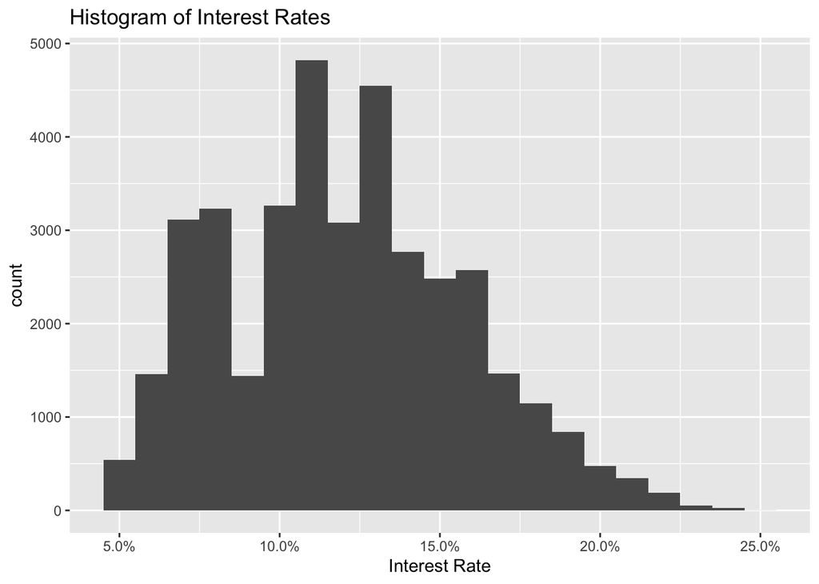

```r
#histogram of interest rtes
ggplot(lc_clean, aes(x=int_rate))+
  geom_histogram(binwidth=0.01)+
  scale_x_continuous(labels = scales::percent) +
  labs(title = "Histogram of Interest Rates",x="Interest Rate")
```

The first histogram may tell us something about the distribution of the interest rates among the borrowers, but does not provide any additional information beyond that.

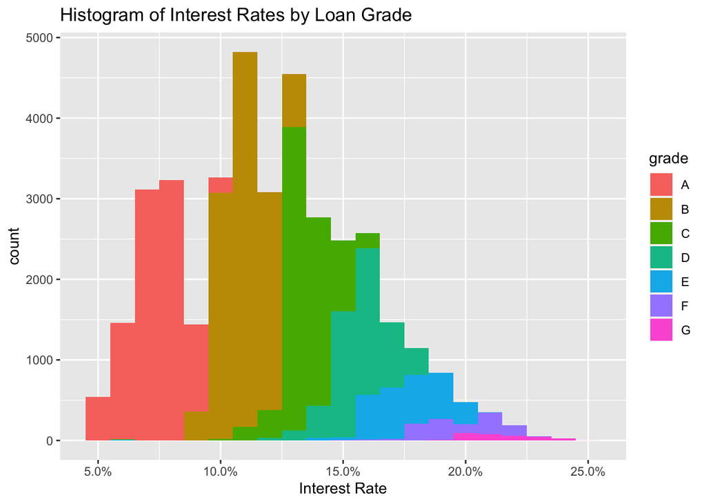

```r
#histogram with colour for different grades
ggplot(lc_clean, aes(x=int_rate, fill=grade))+  geom_histogram(binwidth=0.01)+scale_x_continuous(labels = scales::percent)+ labs(title = "Histogram of Interest Rates by Loan Grade",x="Interest Rate")
```

The second histogram however, provides much deeper insight into what the loans provided, clearly showing a relationsip between the grade of a loan and the associated interest rate.

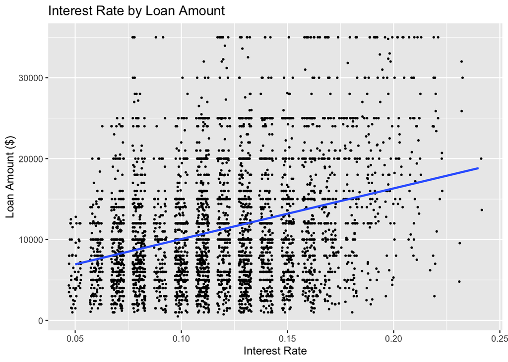

```r
#scatter plot of loan amount against interest rate and add visually the line of best fit
ggplot(lc_clean[seq(1, nrow(lc_clean), 10), ] , aes(x = int_rate, y = loan_amnt)) +
  geom_jitter(width = 0.003, height = 0.002,
              size = 0.5) +
  geom_smooth(method="lm", se=0) +
  labs(title = "Interest Rate by Loan Amount", y="Loan Amount ($)", x="Interest Rate")
```

While the line of fit implies a relationship between the loan amount and the interest rate, the distribution of the points in the scatter plot says otherwise. This plot does not provide any meaningful insight.

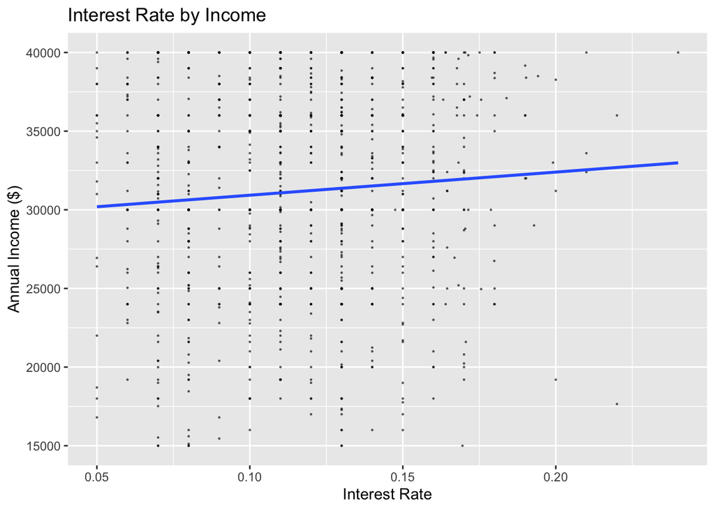

```r
#scatter plot of annual income against interest rate and add visually the line of best fit

ggplot(lc_clean[seq(1, nrow(lc_clean), 10), ] , aes(x = int_rate, y = annual_inc)) +
  geom_point(size=0.2, alpha=0.5)+
  geom_smooth(method="lm", se=0) +
  ylim(15000, 40000)+
  labs(title = "Interest Rate by Income", y="Annual Income ($)", x="Interest Rate")
```

The nearly flat of this scatter plot and line of fit, also does not provide us with much useful information to work with. A transformation might be needed to better visualise the relationship.

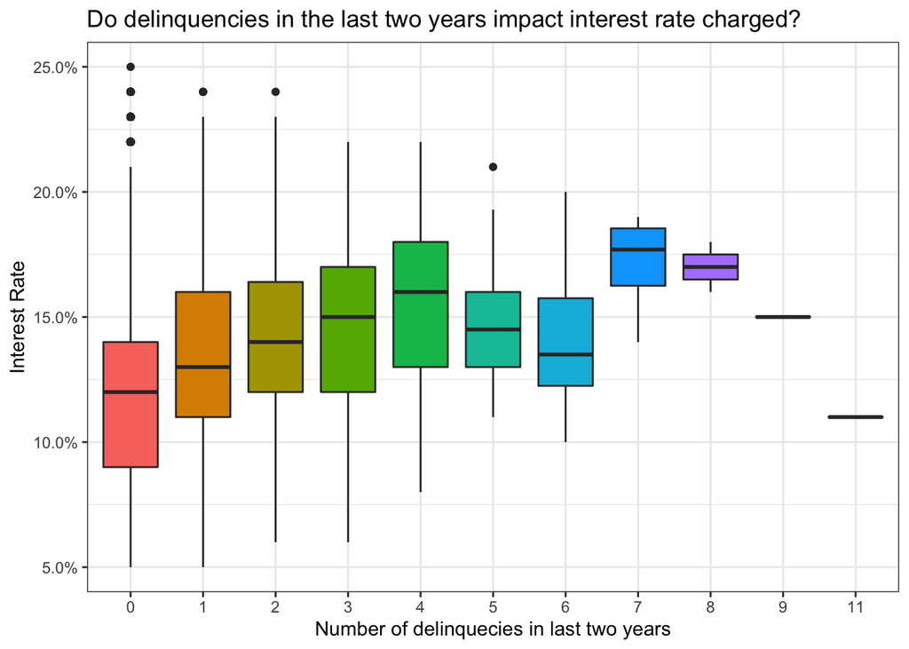

```r
#box plot for delinquencies
ggplot(lc_clean , aes(y=int_rate, x=delinq_2yrs, fill= delinq_2yrs)) +
  geom_boxplot()+
  # geom_jitter()+
  theme_bw()+
   scale_y_continuous(labels=scales::percent)+
  theme(legend.position = "none")+
  labs(
    title = "Do delinquencies in the last two years impact interest rate charged?",
    x= "Number of delinquecies in last two years", y="Interest Rate"
  )
```

We can clearly see from this plot that the number of delinquencies within the past 2 years indeed increases the interest rate charged, up until the 4th delinquency.